# Schéma : babynames

babynames, France, relationnel, pattes de corbeau, crowfoot

babynames

France

crowfoot

DDL

Published

September 20, 2024

Présentation du schéma `babynames`, pour l’entrainement à PostGres.

- **L3 MIASHS/Ingémath**
- **[Université Paris Cité](https://www.u-paris.fr)**
- Année 2024-2025
- [Course Homepage](https://s-v-b.github.io/MA15Y030/)
- [Moodle](https://moodle.u-paris.fr/course/view.php?id=2313)

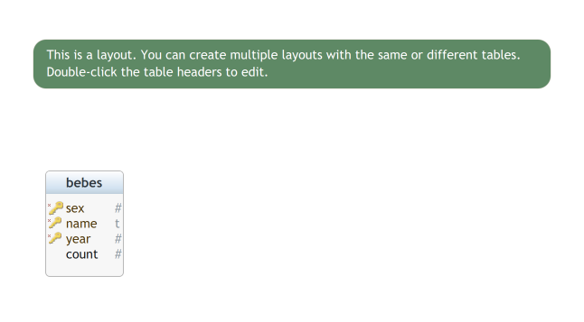

Schema `babynames` Generated using [DbSchema](https://dbschema.com)

Ce jeu de données est fourni par l’INSEE https://www.insee.fr/fr/statistiques/fichier/2540004/nat2021_csv.zip permet d’étudier l’évolution des prénoms donnés en France entre 1900 et aujourd’hui.

Ce schéma ne comporte qu’une seule table.

## Table : `babynames.bebes`

### `sex` (entier)

Description : Représente le sexe des bébés. Valeurs :

- 1 pour Homme
- 2 pour Femme

### `name` (varchar(500))

Description : Le prénom des bébés nés en France. Type : Chaîne de caractères variable d’une longueur maximale de 500 caractères.

### `year` (nombre entier) :

Description : L’année de naissance des bébés ayant reçu un certain prénom. Type : Entier

### `count` (nombre entier) :

Description : Nombre de bébés d’un sexe donné, portant un nom particulier, nés au cours d’une année donnée.

## Exemple de données

```
+---+------+-----+-----+
|sex| name | year|count|
+---+------+-----+-----+
| 1 |Liam  | 2020| 350 |
| 2 |Emma  | 2020| 420 |
| 1 |Noah  | 2019| 340 |
| 2 |Olivia| 2019| 390 |
```

## Usages

Cet ensemble de données peut être utilisé pour

- Analyser les tendances de popularité : Déterminer les prénoms les plus populaires pour les garçons et les filles au fil du temps.
- Suivre l’évolution des tendances en matière de noms : Comprendre comment certains prénoms gagnent ou perdent en popularité au fil des années.
- Analyse fondée sur le sexe : Comparer la façon dont certains noms sont spécifiques à un sexe ou partagés par les hommes et les femmes.
- Recherche historique : Explorer les tendances culturelles ou sociétales qui se reflètent dans les conventions de dénomination des bébés.

## Synthèse

| Idx | Name | Data Type |
| --- | --- | --- |
| * 🔑 | sex | integer |
| * 🔑 | name | varchar(500) |
| * 🔑 | year | integer |
|  | count | integer |